# Report of Beer Tweets

Team Where’s Ivy

November 8, 2017

For this project we were interested in exploring twitter data on beer companies. Our inital thought was to look at twitter marketing aimed toward youth. With limited access to age data from twitter (a paid data source) we redefined our questions listed below.

# Process

We choose 5 brands of beer from different multinational companies around the world for our analysis.Budlight, Dos Equis, Guinness U.S., Blue Moon and Tsingtao. Each of us cleaned the data for our assigned beer companies and we merged our clean data. Our data wrangleing file was sent to you separately due to twitter authorization code privacy.

# Our data visualization files answering our respective questions above are attached:

- The only file you need to run is the makefile.R

# Questions

1. Derrick, Sentiment Analysis by day of the week, Does sentiment analysis change over the course of the week by each beer company?

Here is the density of sentiment scores for all beer companies. As we see, the vast majority of sentiments are positive, which makes sense for the alcohol industry. However, once we break it down per individual company, we see that they differ a little bit. Most notable, is how much more positive the Blue Moon tweets are than every other company. Also interesting to note that the positivity does not increase that significantly as the week approaches the weekend. This significance could be tested with a linear regression model.

[figure not shown]

Average Sentiment Score as the week progresses to the weekend

2. Michael, Thematic Topic Modeling, What are the most popular topics overall?

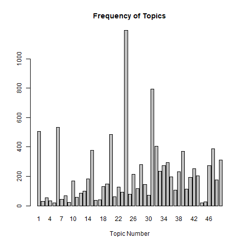

Most Popular Topics by Frequency.

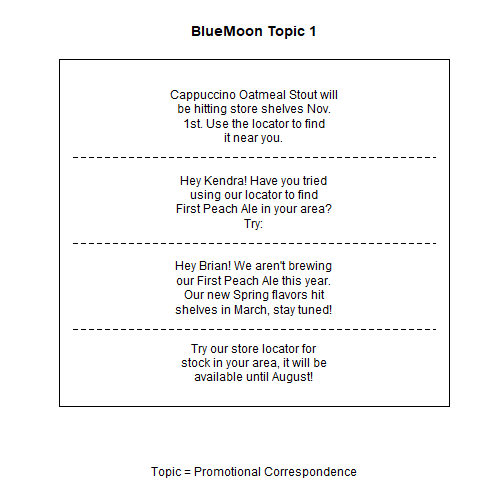

Most Tweeted & Favorited Topic - Blue Moon

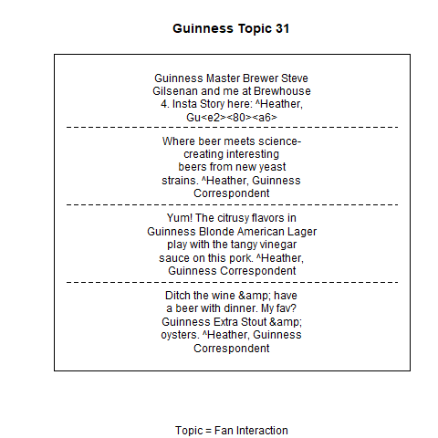

Most Tweeted & Favorited Topic - Guiness

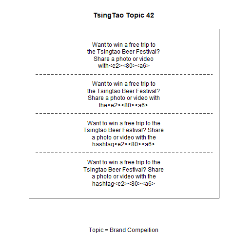

Most Tweeted & Favorited Topic - TsingTao

[figure not shown]

Most Tweeted & Favorited Topic - Bud Light

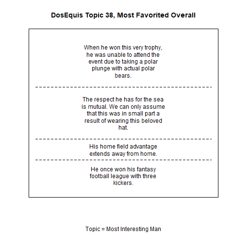

Most Tweeted & Favorited Topic - Dos Equis

3. Tess, What are the most popular topics on Saturdays across the 5 companies?

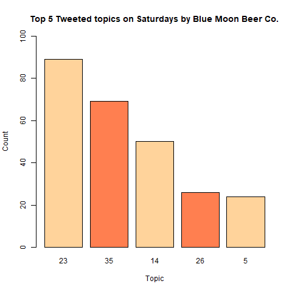

Top 5 Tweeted topics on Saturdays by Blue Moon Beer Co.

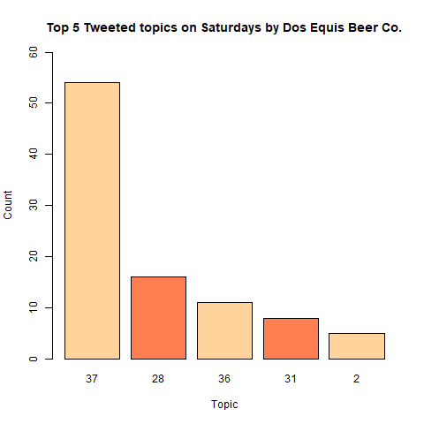

Top 5 Tweeted topics on Saturdays by Dos Equis Beer Co.

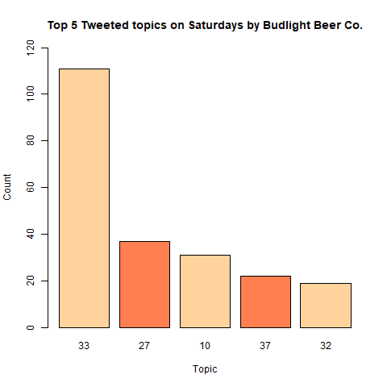

Top 5 Tweeted topics on Saturdays by Budlight Beer Co.

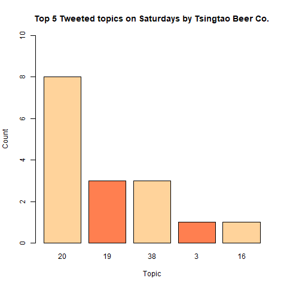

Top 5 Tweeted topics on Saturdays by Tsingtao Beer Co.

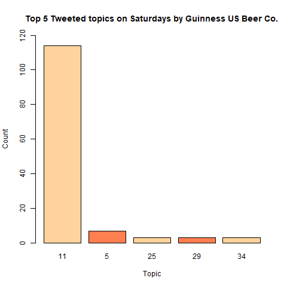

Top 5 Tweeted topics on Saturdays by Guinness US Beer Co.

4. Lisha, Among the highest retweets each month, which are the most popular words?

The most popular words among tweets with monthly highest retweets are world and dos. Both of them appear 6 times. Dos is the brand name, and in the past few years, 50 tweets published by DosEquis got highest retweets in the month they had been published, which exceeds all other companies’ tweets. We can conclude that DosEquis is the most influential twitter account among the five beer companies’ accounts. Other popular words such as game, party, and night describe the time and places that people drink beers, which corresponds to our impression.

The table below display the number of months each company has the highest retweets

| Brand | Count |
| --- | --- |
| BlueMoonBrewCo | 3 |
| budlight | 3 |
| DosEquis | 50 |
| GuinnessUS | 8 |
| tsingtao | 3 |

5. David, What are the most frequently used words by each company?

The words most frequently used throughout all 5 companies were “Beer” and “Cheers” among all of the beer companies we analyzed. However, some companies such as Guinness and Tsingtao also tweeted their own name brand at a high frequency while Dos Equis’ most frequently tweeted the phrase ‘staythirsty’ in reference to their brand’s catch phrase.

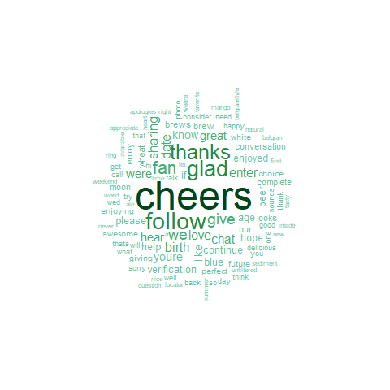

Most Frequently tweeted words by Blue Moon Beer Co.

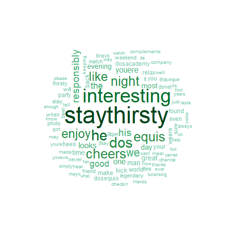

Most Frequently tweeted words by Dos Equis Beer Co.

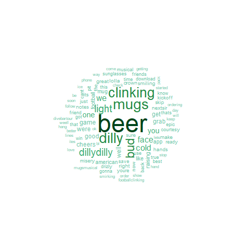

Most Frequently tweeted words by Budlight Beer Co.

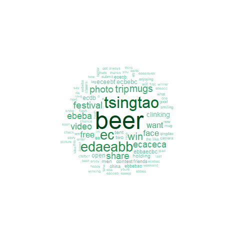

Most Frequently tweeted words by Tsingtao Beer Co.

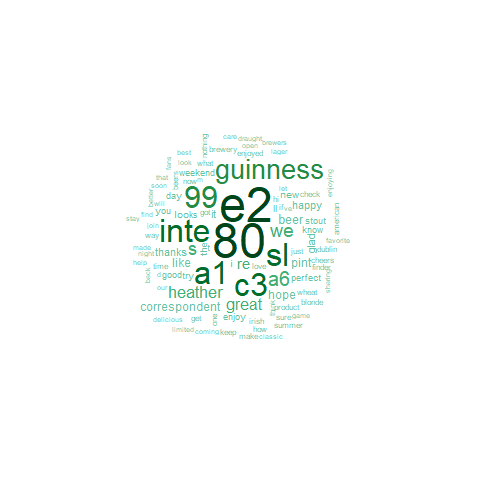

Most Frequently tweeted words by Guinness US Beer Co..

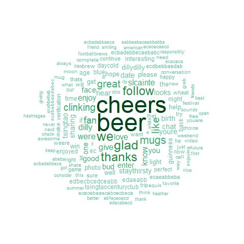

Most Frequently tweeted words by All 5 Beer Companies